# Proportion of fear of own neighborhood by race

## Setup

### Load packages

```r
library(ggplot2)
library(dplyr)
library(statsr)
library(tidyr)
setwd("~/Desktop/statsWithR/statswithr_week10")
```

### Load data

```r
load("gss.Rdata")
```

## Part 1: Data

The GSS is conducted on even-numbered years. Most samples are obtained via face-to-face interviews. If the respondent is not available to meet in-person, the interview will take place over the phone.

The sample size varies yearly, but is mostly in the high 2,000s.

The population of interest is adults living in households in the U.S.

As an observational study, the GSS is conducted by random sampling, which means the results can be generalized to the population. However, since there is no random assignment, the survey cannot be used to infer causal relationships.

## Part 2: Research question

Do whites and blacks fear walking at night in their neighborhood at the same rate?

This question interests me because I’ve seen many articles covering racial bias in the way police interact with blacks, and how blacks fear police, but I haven’t read anything about the way whites and blacks fear their own surroundings.

## Part 3: Exploratory data analysis

Here’s a line chart showing the proportion of people fearing their own neighborhood over time.

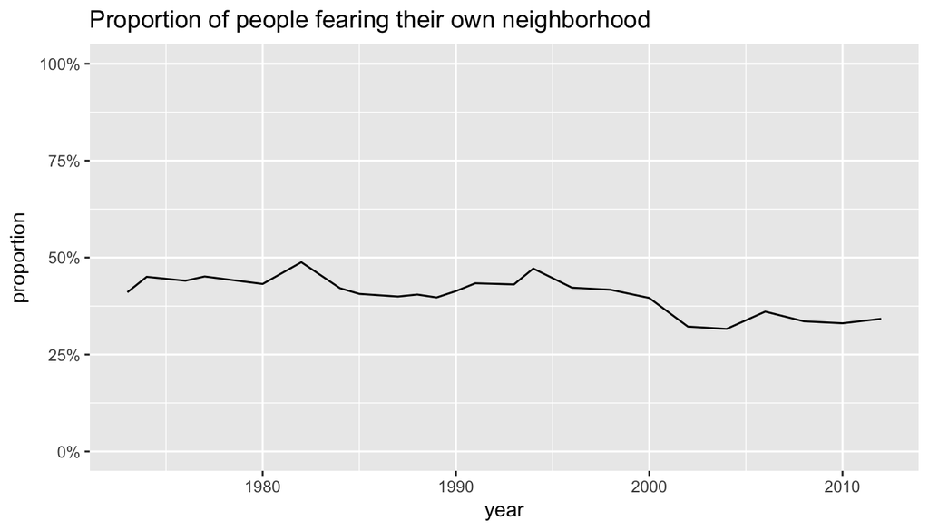

```r
gss %>%
    select(year, fear) %>%
    na.omit %>%
    count(year, fear) %>%
    mutate(proportion = n / sum(n)) %>%
    filter(fear == 'Yes') %>%
    ggplot(aes(year, proportion)) +
    geom_line() +
    scale_y_continuous(labels = scales::percent, limits=c(0, 1)) +
    labs(title='Proportion of people fearing their own neighborhood')
```

And here’s how that line is broken down by race.

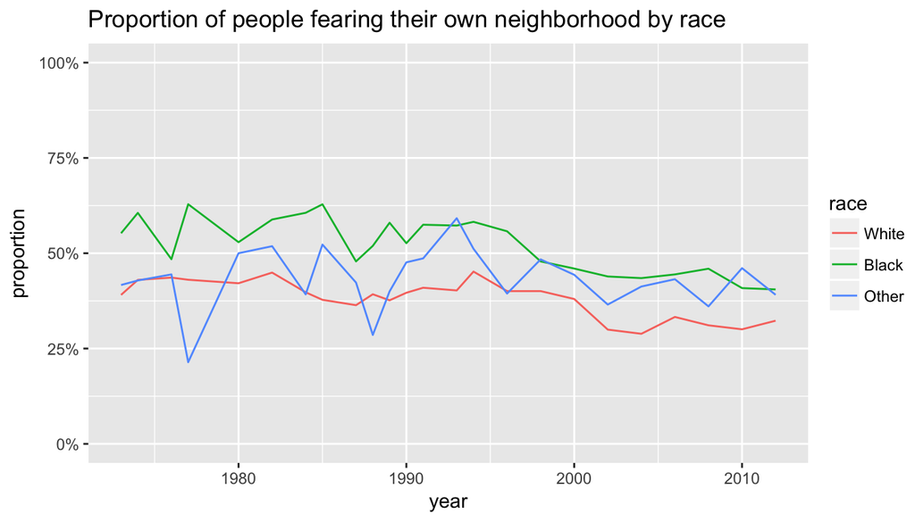

```r
data <- gss %>%
    select(year, race, fear) %>%
    na.omit %>%
    count(year, race, fear) %>%
    mutate(proportion = n / sum(n))

data %>%
    filter(fear == 'Yes') %>%
    ggplot(aes(year, proportion, color=race)) +
    geom_line() +
    scale_y_continuous(labels = scales::percent, limits=c(0, 1)) +
    labs(title='Proportion of people fearing their own neighborhood by race')
```

Here’s a table showing the white and black fear estimates for the latest year.

```r
data %>%
    filter(fear == 'Yes', race %in% c('White', 'Black')) %>%
    select(-n, -fear) %>%
    arrange(year) %>%
    spread(race, proportion) %>%
    tail(1)
```

```
## Source: local data frame [1 x 3]
## Groups: year [1]
##
##    year     White     Black
##   <int>     <dbl>     <dbl>
## 1  2012 0.3230453 0.4051282
```

Note that the black proportion estimate is always higher than the white estimate. What can we infer about the population?

## Part 4: Inference

#### Hypotheses

$H_0: p_b - p_w = 0$, i.e. the proportion of blacks that fear walking at night in their own neighborhood is the same as that of whites, **in 2012**.

$H_A: p_b - p_w \neq 0$, i.e. the proportion of blacks that fear walking at night in their own neighborhood is different than that of whites, **in 2012**.

#### Check conditions

**Independence:** Each group is a random sample from less than 10% of the population, therefore the observations are independent.

**Success-failure condition:** Each group has at least 10 successes and failures.

#### Method

I’ll conduct a two-proportion hypothesis test with a pooled proportion **for 2012**.

#### Inference

**Latest year (2012):**

```r
gss_2012 <- gss %>%
    filter(year == 2012, race %in% c('White', 'Black')) %>%
    select(fear, race) %>%
    mutate(race = as.factor(as.character(race))) %>%
    filter(complete.cases(.))

inference(y = fear, x = race, data = gss_2012, statistic = 'proportion', type = 'ht', null = 0, alternative = 'twosided', method = 'theoretical', success = 'Yes')
```

```
## Response variable: categorical (2 levels, success: Yes)
## Explanatory variable: categorical (2 levels)
## n_Black = 195, p_hat_Black = 0.4051
## n_White = 972, p_hat_White = 0.323
## H0: p_Black =  p_White
## HA: p_Black != p_White
## z = 2.2135
## p_value = 0.0269
```

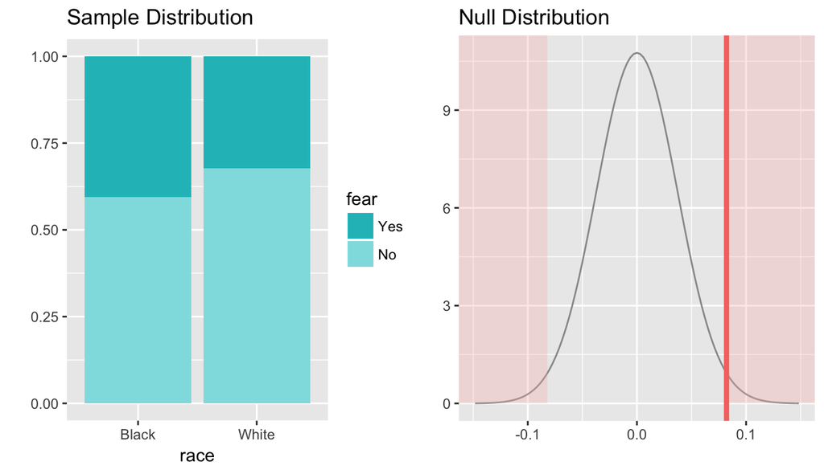

#### Interpret results

The p-value $\leq 0.05$, therefore we reject $H_0$, that in 2012, the proportion of blacks that fear walking at night in their own neighborhood is the same as that of whites.